# Practical Machine Learning Course Project Report

by Andrii Unghur

## Introduction

Using devices such as Jawbone Up, Nike FuelBand, and Fitbit it is now possible to collect a large amount of data about personal activity relatively inexpensively. These type of devices are part of the quantified self movement – a group of enthusiasts who take measurements about themselves regularly to improve their health, to find patterns in their behavior, or because they are tech geeks. One thing that people regularly do is quantify how much of a particular activity they do, but they rarely quantify how well they do it.

In this project, we will use data from accelerometers on the belt, forearm, arm, and dumbell of 6 participants to predict the manner in which they did the exercise.

## How the Model Was Built

Using the “classe” variable and other predictors - the model will be built using decision tree, random forest and gradient boosting algorithm.

## Cross-Validation

Cross-validation will be performed on the training set and the testing set to aid in estimating the prediction error. This resampling method will take the model and divide it into two sub-sample sets. The sub-training set will be used to to build the model, and the sub-testing set will be used to validate the model. The more accurate subset will be tested against the original set.

## Expected Out of Sample Error

Out of Sample Error is “the error rate you get on a new data set”. The expectation is that the out-of-sample error will correlate with the accuracy of the cross-validation data. Based on results of cross-validation, the out of sample error will be the proportion of misclassified cases over the total cases in the test data.

## Explanation of Prediction Model

# Loading the data and libraries

```r
library(ggplot2)
library(lattice)
library(caret)
library(randomForest)
library(rattle)
library(rpart)
library(gridExtra)
library(tidyr)
```

Download files from the data source, and read the two csv files into two data frames.

```r
TrainDataUrl <-"https://d396qusza40orc.cloudfront.net/predmachlearn/pml-training.csv"
TestDataUrl <- "https://d396qusza40orc.cloudfront.net/predmachlearn/pml-testing.csv"
TrainFile <- "./data/pml-training.csv"
TestFile  <- "./data/pml-testing.csv"

if (!file.exists("./data")) {
  dir.create("./data")
}
if (!file.exists(TrainFile)) {
  download.file(TrainDataUrl, destfile=TrainFile, method="curl")
}
if (!file.exists(TestFile)) {
  download.file(TestDataUrl, destfile=TestFile, method="curl")
}
```

Make sure we will get NA values for ’‘, ’NA’, ‘#Div/0!’

```r
TrainData <- read.csv("./data/pml-training.csv",header=TRUE, as.is = TRUE, stringsAsFactors = FALSE, sep=',', na.strings=c("NA","#DIV/0!",""))
ValidationData <- read.csv("./data/pml-testing.csv",header=TRUE, as.is = TRUE, stringsAsFactors = FALSE, sep=',', na.strings=c("NA","#DIV/0!",""))
```

After investigating of all the variables in the sets, we see that there are a lot of NA values. We will remove the variables that contains missing values and then will remove the first seven variables as they have little impact on the outcome classe

```r
TrainDataClean <- TrainData[,colSums(is.na(TrainData))==0]
TrainDataClean <- TrainDataClean[,-c(1:7)]
dim(TrainDataClean)
```

```
## [1] 19622    53
```

```r
ValidationDataClean <- ValidationData[,colSums(is.na(ValidationData))==0]
ValidationDataClean <- ValidationDataClean[,-c(1:7)]
dim(ValidationDataClean)
```

```
## [1] 20 53
```

```r
set.seed(136)
inTrain <- createDataPartition(TrainDataClean$classe, p = 0.7, list = FALSE)
TrainDataClean <- TrainDataClean[inTrain, ]
TestData <- TrainDataClean[-inTrain, ]
dim(TrainDataClean)
```

```
## [1] 13737    53
```

```r
dim(TestData)
```

```
## [1] 4114   53
```

## Prediction with Decision Trees

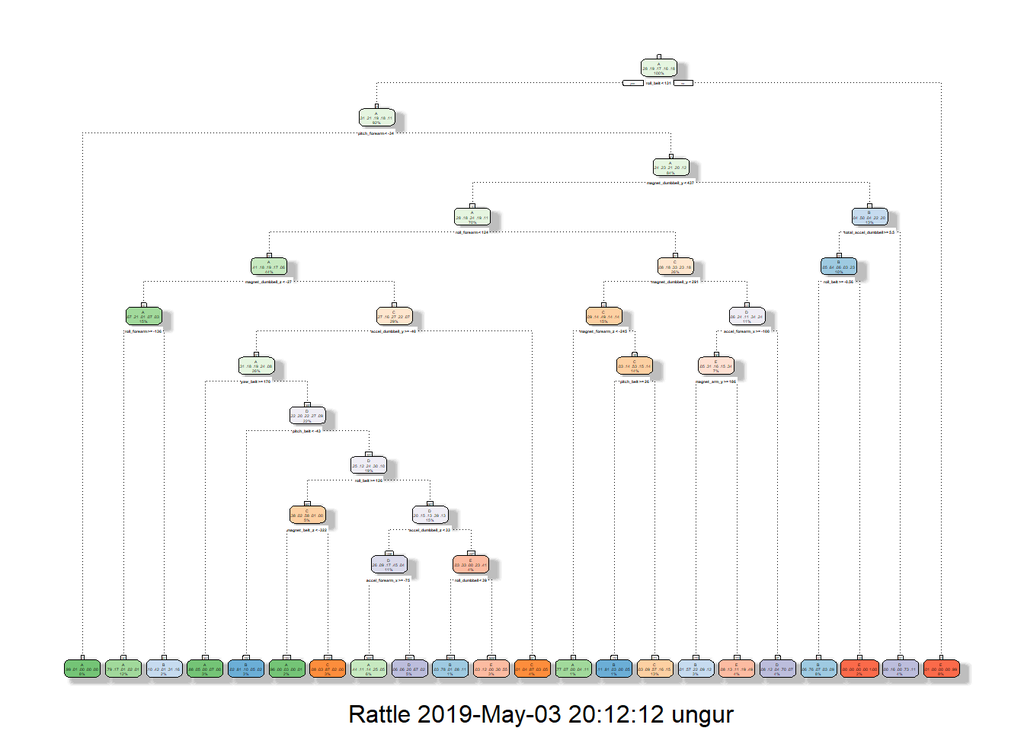

```r
decisonTree <- rpart(classe ~ ., data=TrainDataClean, method="class")
fancyRpartPlot(decisonTree)
```

Accuracy

```r
predictionsDecTree <- predict(decisonTree, TestData, type = "class")
cmtree <- confusionMatrix(table(predictionsDecTree, TestData$classe))
cmtree
```

```
## Confusion Matrix and Statistics
##
##
## predictionsDecTree    A    B    C    D    E
##                  A 1044  119   12   39   12
##                  B   41  472   52   41   65
##                  C   33   83  625   97   80
##                  D   38   58   45  472   40
##                  E   19   37   10   44  554
##
## Overall Statistics
##
##                Accuracy : 0.7665
##                  95% CI : (0.7532, 0.7793)
##     No Information Rate : 0.2844
##     P-Value [Acc > NIR] : < 2.2e-16
##
##                   Kappa : 0.7043
##
##  Mcnemar's Test P-Value : < 2.2e-16
##
## Statistics by Class:
##
##                      Class: A Class: B Class: C Class: D Class: E
## Sensitivity            0.8885   0.6138   0.8401   0.6811   0.7377
## Specificity            0.9385   0.9408   0.9135   0.9474   0.9675
## Pos Pred Value         0.8515   0.7034   0.6808   0.7228   0.8343
## Neg Pred Value         0.9549   0.9142   0.9630   0.9365   0.9432
## Prevalence             0.2844   0.1861   0.1801   0.1677   0.1818
## Detection Rate         0.2527   0.1142   0.1513   0.1142   0.1341
## Detection Prevalence   0.2967   0.1624   0.2222   0.1580   0.1607
## Balanced Accuracy      0.9135   0.7773   0.8768   0.8142   0.8526
```

```r
cmtree$table
```

```
##
## predictionsDecTree    A    B    C    D    E
##                  A 1044  119   12   39   12
##                  B   41  472   52   41   65
##                  C   33   83  625   97   80
##                  D   38   58   45  472   40
##                  E   19   37   10   44  554
```

```r
cmtree$overall[1]
```

```
##  Accuracy
## 0.7664569
```

```r
trControl <- trainControl(method = "cv", number = 5)
model_RF <- train(classe~., data=TrainDataClean, method="rf", trControl=trControl, verbose=FALSE)
```

Printing result

```r
print(model_RF)
```

```
## Random Forest
##
## 13737 samples
##    52 predictor
##     5 classes: 'A', 'B', 'C', 'D', 'E'
##
## No pre-processing
## Resampling: Cross-Validated (5 fold)
## Summary of sample sizes: 10988, 10990, 10989, 10990, 10991
## Resampling results across tuning parameters:
##
##   mtry  Accuracy   Kappa
##    2    0.9901001  0.9874756
##   27    0.9914831  0.9892260
##   52    0.9826025  0.9779897
##
## Accuracy was used to select the optimal model using the largest value.
## The final value used for the model was mtry = 27.
```

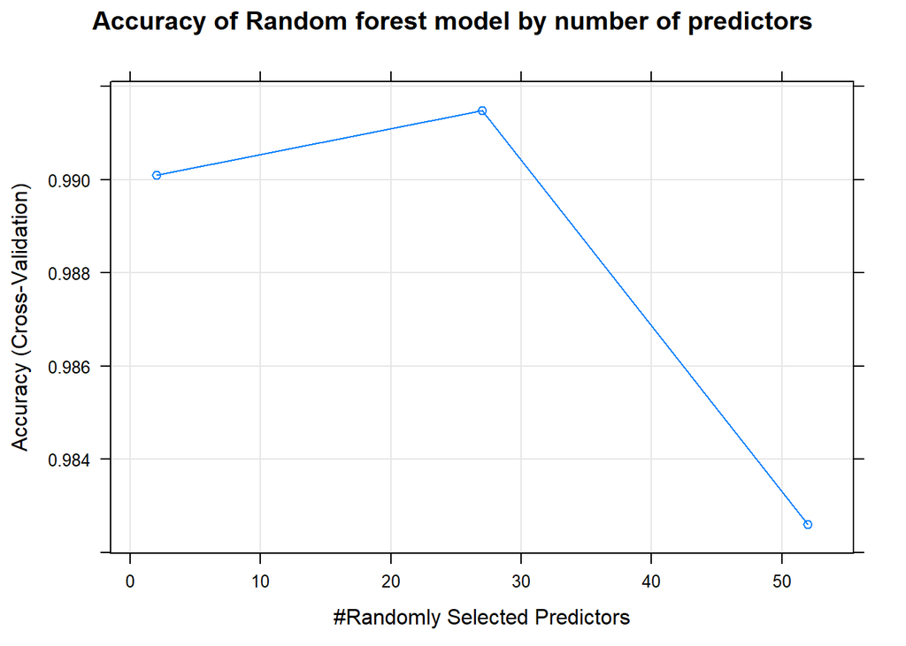

```r
plot(model_RF,main="Accuracy of Random forest model by number of predictors")
```

```r
trainpred <- predict(model_RF,newdata=TestData)

confMatRF <- confusionMatrix(table(trainpred,TestData$classe))
```

Displaying confusion matrix and model accuracy

```r
confMatRF$table
```

```
##
## trainpred    A    B    C    D    E
##         A 1151    0    0    0    0
##         B    0  826    0    0    0
##         C    0    0  713    0    0
##         D    0    0    0  673    0
##         E    0    0    0    0  751
```

```r
confMatRF$overall[1]
```

```
## Accuracy
##        1
```

```r
names(model_RF$finalModel)
```

```
##  [1] "call"            "type"            "predicted"
##  [4] "err.rate"        "confusion"       "votes"
##  [7] "oob.times"       "classes"         "importance"
## [10] "importanceSD"    "localImportance" "proximity"
## [13] "ntree"           "mtry"            "forest"
## [16] "y"               "test"            "inbag"
## [19] "xNames"          "problemType"     "tuneValue"
## [22] "obsLevels"       "param"
```

```r
model_RF$finalModel$classes
```

```
## [1] "A" "B" "C" "D" "E"
```

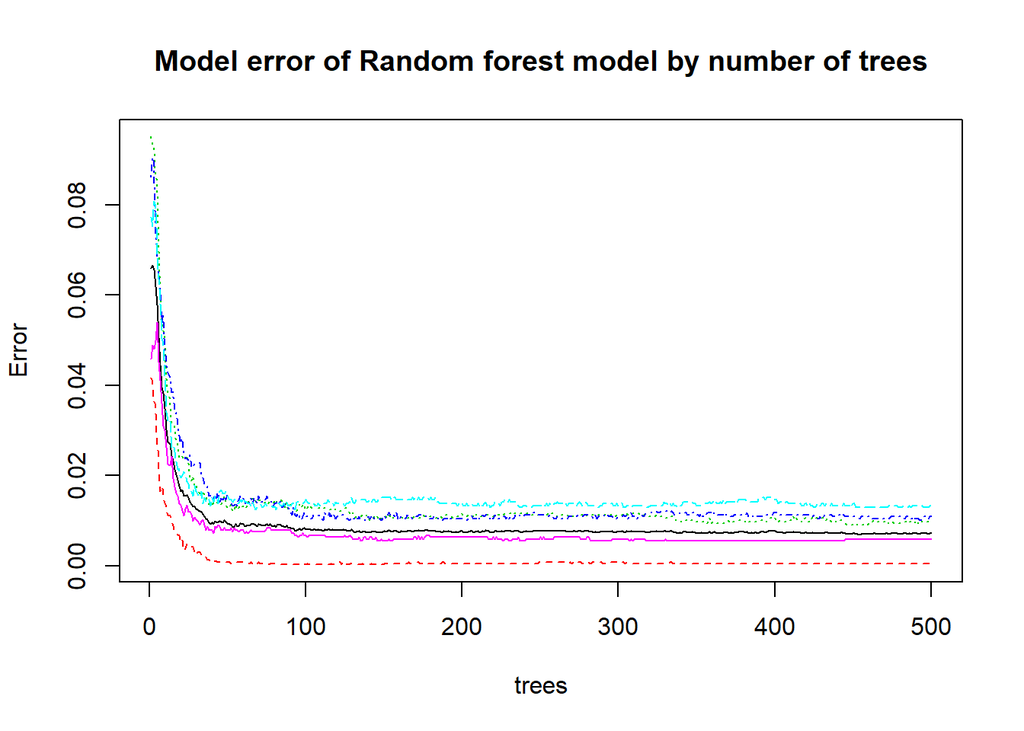

```r
plot(model_RF$finalModel,main="Model error of Random forest model by number of trees")
```

## Train with gradient boosting method

```r
model_GBM <- train(classe~., data=TrainDataClean, method="gbm", trControl=trControl, verbose=FALSE)
print(model_GBM)
```

```
## Stochastic Gradient Boosting
##
## 13737 samples
##    52 predictor
##     5 classes: 'A', 'B', 'C', 'D', 'E'
##
## No pre-processing
## Resampling: Cross-Validated (5 fold)
## Summary of sample sizes: 10989, 10990, 10991, 10989, 10989
## Resampling results across tuning parameters:
##
##   interaction.depth  n.trees  Accuracy   Kappa
##   1                   50      0.7527140  0.6864832
##   1                  100      0.8212859  0.7736990
##   1                  150      0.8544081  0.8157519
##   2                   50      0.8557923  0.8172782
##   2                  100      0.9095885  0.8855813
##   2                  150      0.9315000  0.9133126
##   3                   50      0.8989602  0.8720894
##   3                  100      0.9430746  0.9279665
##   3                  150      0.9613458  0.9510952
##
## Tuning parameter 'shrinkage' was held constant at a value of 0.1
##
## Tuning parameter 'n.minobsinnode' was held constant at a value of 10
## Accuracy was used to select the optimal model using the largest value.
## The final values used for the model were n.trees = 150,
##  interaction.depth = 3, shrinkage = 0.1 and n.minobsinnode = 10.
```

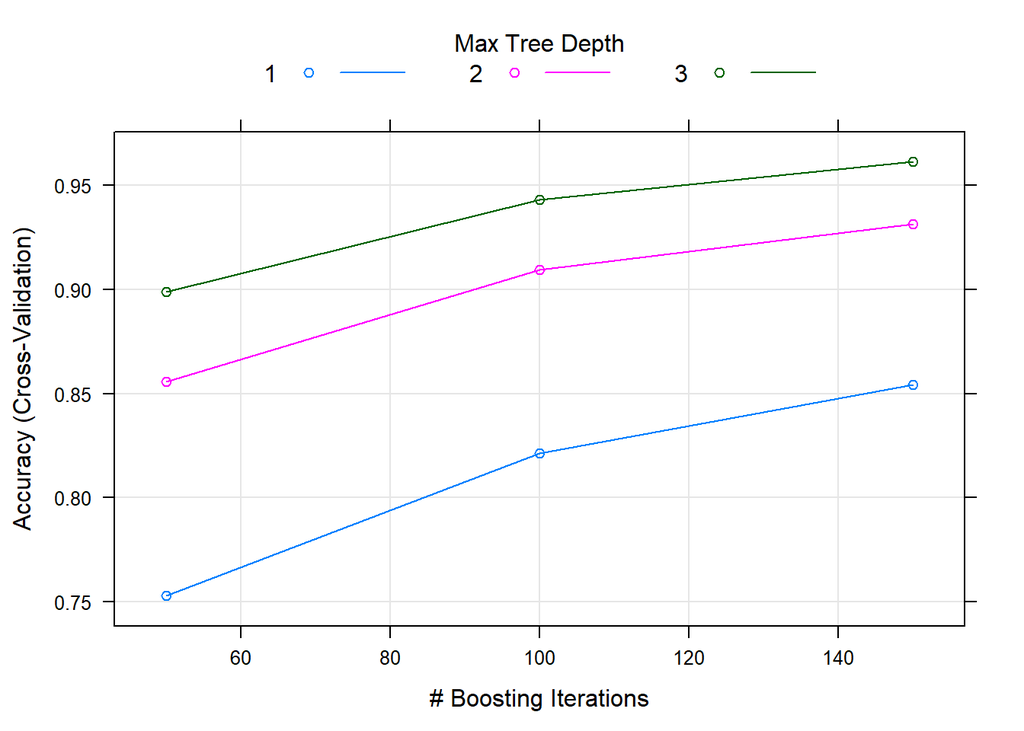

```r
plot(model_GBM)
```

```r
trainpred <- predict(model_GBM,newdata=TestData)

confMatGBM <- confusionMatrix(table(TestData$classe,trainpred))
confMatGBM$table
```

```
##    trainpred
##        A    B    C    D    E
##   A 1141    7    1    2    0
##   B   16  788   22    0    0
##   C    0   11  693    9    0
##   D    1    3   13  656    0
##   E    2    6    4   11  728
```

```r
confMatGBM$overall[1]
```

```
##  Accuracy
## 0.9737482
```

## Conclusion

This shows that the random forest model is the best one. We will use it to predict the values of classe for the validation data set.

```r
FinalTestPred <- predict(model_RF,newdata=ValidationDataClean)
FinalTestPred
```

```
##  [1] B A B A A E D B A A B C B A E E A B B B
## Levels: A B C D E
```